# Precipitant-stratified 30-day readmission after type 2 myocardial infarction

# 13 Model diagnostics

Table S4. Model diagnostics.

| Diagnostic | Value | Interpretation |
| --- | --- | --- |
| Maximum variance inflation factor (per design-matrix column) | 3.55 | Below the pre-specified threshold of 5; no collinearity concern |
| Maximum VIF among the seven precipitant dummy columns | 1.72 | Reported separately because the exposure contributes seven dummy columns; an inflated value here would indicate that a covariate still overlaps a precipitant class despite the pre-specified removals |
| Survey-weighted c-statistic (tie-corrected) | 0.622 | Reported without a threshold; discrimination is not the objective of an aetiological model |
| Design-based decile calibration test (survey analogue of Hosmer-Lemeshow) | <0.001 | With a cohort of this size any calibration test will reject. Figure S3 is the substantive evidence; this p-value is reported for completeness only and is not interpreted alone. |
| Covariates removed by the sparse-cell guard | None | Every removal is named here and in the Methods section |
| Minimum unweighted cell enforced on every reported table | 11 | HCUP Data Use Agreement |

Variance inflation factors are computed per design-matrix column rather than aggregated to a generalized VIF, which is the conservative reading: if no individual dummy column is inflated then no multi-level factor is either. The maximum among the seven precipitant dummy columns is reported separately, because the pre-specified removal of five Elixhauser flags was justified on the grounds that they overlap precipitant classes by construction, and this is the number that shows whether that removal succeeded. The c-statistic is survey-weighted and tie-corrected. The calibration test is the survey analogue of the Hosmer-Lemeshow test and is NOT the Archer-Lemeshow F-adjusted mean residual test; it should not be described as such. Singleton strata were centred at the grand mean (survey.lonely.psu = ‘adjust’) rather than removed; 5 stratum/strata contained a single primary sampling unit. All manually constructed intervals use t critical values on 8,928 design degrees of freedom rather than 1.96.

Table S4b. Variance inflation factors, per design-matrix column.

| Term | VIF |
| --- | --- |
| Age, natural-spline basis 1 | 3.55 |
| Age, natural-spline basis 3 | 2.9 |
| Hypertension, complicated | 2.63 |
| Age, natural-spline basis 2 | 2.42 |
| Discharge year: 2022 | 2.26 |
| Discharge year: 2021 | 2.16 |
| Discharge year: 2020 | 2.03 |
| Hospital bed size: Large | 2.01 |
| Congestive heart failure | 1.91 |
| Hospital bed size: Medium | 1.9 |
| Hospital location and teaching status: Non-metropolitan | 1.89 |
| Discharge year: 2019 | 1.88 |
| Hypertension, uncomplicated | 1.88 |
| Patient residence (NCHS urban-rural classification): Micropolitan | 1.75 |
| Tachyarrhythmia (vs Sepsis or severe infection) | 1.72 |
| None of the above (vs Sepsis or severe infection) | 1.65 |
| Median household income quartile (patient ZIP code): 76th to 100th percentile | 1.64 |
| Primary expected payer: Medicaid | 1.55 |
| Median household income quartile (patient ZIP code): 51st to 75th percentile | 1.53 |
| Patient residence (NCHS urban-rural classification): Fringe metro ≥1 million | 1.48 |
| Median household income quartile (patient ZIP code): 26th to 50th percentile | 1.46 |
| Chronic kidney disease stage: Stage 3 | 1.46 |
| Known coronary artery disease (I25.1x/I25.7x) | 1.44 |
| Patient residence (NCHS urban-rural classification): Metro 250,000-999,999 | 1.41 |
| Metastatic cancer | 1.4 |
| Solid tumour without metastasis | 1.4 |
| Chronic kidney disease stage: Dialysis-dependent / ESKD | 1.37 |
| Patient residence (NCHS urban-rural classification): Other | 1.35 |
| Primary expected payer: Private | 1.34 |
| Patient residence (NCHS urban-rural classification): Metro 50,000-249,999 | 1.34 |
| Hospital location and teaching status: Metropolitan, teaching | 1.34 |
| Prior revascularization (Z95.1/Z95.5) | 1.3 |
| Acute respiratory failure (vs Sepsis or severe infection) | 1.29 |
| Acute GI bleed or blood-loss anaemia (vs Sepsis or severe infection) | 1.27 |
| Diabetes, complicated | 1.27 |
| Hypertensive emergency (vs Sepsis or severe infection) | 1.26 |
| Drug abuse | 1.21 |
| Chronic kidney disease stage: Stage 4-5, not on dialysis | 1.21 |
| Chronic kidney disease stage: Unspecified stage | 1.19 |
| Invasive mechanical ventilation at index | 1.18 |
| Hypovolaemia or non-cardiogenic shock (vs Sepsis or severe infection) | 1.16 |
| Primary expected payer: Other/self-pay | 1.14 |
| Alcohol abuse | 1.14 |
| Sex: Female | 1.13 |
| Other neurological disorders | 1.12 |
| Liver disease | 1.12 |
| Obesity | 1.12 |
| Coronary angiography or cardiac catheterization at index | 1.12 |
| Valvular disease | 1.11 |
| Hospital ownership: Private, invest-own | 1.1 |
| Chronic pulmonary disease | 1.08 |
| Weight loss | 1.08 |
| Patient residence (NCHS urban-rural classification): Missing/other | 1.07 |
| Diabetes, uncomplicated | 1.07 |
| Coagulopathy | 1.07 |
| Perioperative (vs Sepsis or severe infection) | 1.06 |
| Pulmonary circulation disorders | 1.06 |
| Hypothyroidism | 1.06 |
| Cardiogenic shock at index | 1.06 |
| Chronic kidney disease stage: Stage 1-2 | 1.06 |
| Hospital ownership: Government, nonfederal | 1.05 |
| Peripheral vascular disorders | 1.05 |
| Median household income quartile (patient ZIP code): Missing/other | 1.04 |
| Depression | 1.03 |
| Admission type: Elective | 1.02 |
| Paralysis | 1.02 |
| Rheumatoid arthritis / collagen vascular disease | 1.02 |
| Psychoses | 1.02 |
| Peptic ulcer disease | 1.01 |
| HIV/AIDS | 1.01 |
| Lymphoma | 1.01 |
| Primary expected payer: Missing/other | 1 |
| Admission day: Weekend (Sat-Sun) | 1 |

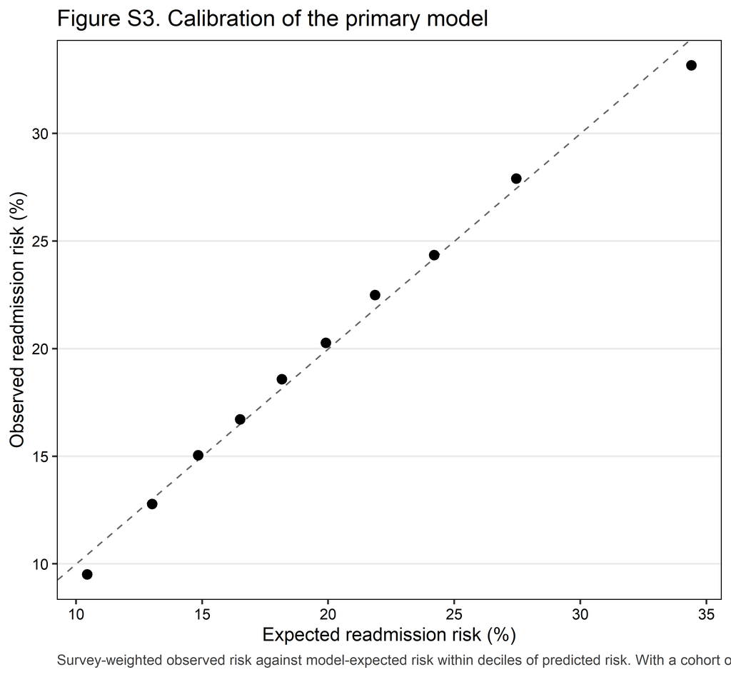

Figure S3. Calibration of the primary model.

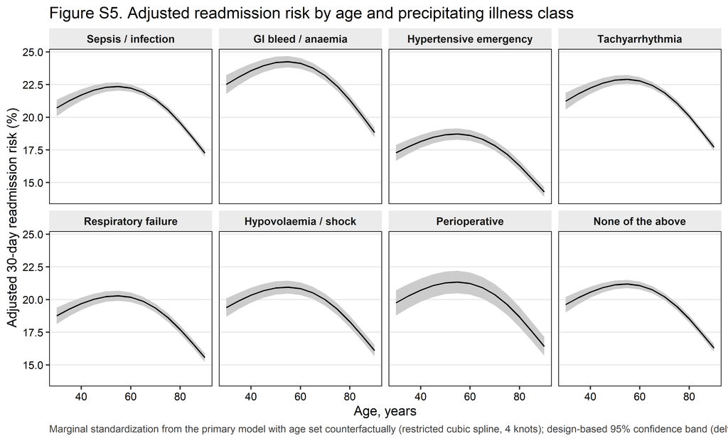

Figure S5. Adjusted readmission risk by age and precipitating illness class.

# 14 Missing data and code lists

Table S7. Missingness on primary-model covariates (only covariates with any missing value).

| Variable | Missing n | Missing % | Handling |
| --- | --- | --- | --- |
| Admission type | 650 | 0.07% | Complete case |

Categorical covariates retain an explicit ‘Missing/other’ level; only continuous covariates and variables with no defensible missing category are complete-cased. The pre-specified trigger for multiple imputation is 5% missingness on any primary-model covariate.

Table S9. Complete code lists, exactly as matched (SAP A17).

| Group | System | Code |
| --- | --- | --- |
| Type 2 myocardial infarction (any-listed, index cohort) | ICD-10-CM | I21A1 |
| Other myocardial infarction type (excluded, not pooled) | ICD-10-CM | I21A9 |
| Type 1 myocardial infarction (contamination exclusion; comparator arm) | ICD-10-CM | I210 (prefix) |
| Type 1 myocardial infarction (contamination exclusion; comparator arm) | ICD-10-CM | I211 (prefix) |
| Type 1 myocardial infarction (contamination exclusion; comparator arm) | ICD-10-CM | I212 (prefix) |
| Type 1 myocardial infarction (contamination exclusion; comparator arm) | ICD-10-CM | I213 (prefix) |
| Type 1 myocardial infarction (contamination exclusion; comparator arm) | ICD-10-CM | I214 (prefix) |
| Type 1 myocardial infarction (contamination exclusion; comparator arm) | ICD-10-CM | I219 (prefix) |
| Type 1 myocardial infarction (contamination exclusion; comparator arm) | ICD-10-CM | I22 (prefix) |
| Precipitant rank 1: sepsis or severe infection | ICD-10-CM | A40 (prefix) |
| Precipitant rank 1: sepsis or severe infection | ICD-10-CM | A41 (prefix) |
| Precipitant rank 1: sepsis or severe infection | ICD-10-CM | R6520 (prefix) |
| Precipitant rank 1: sepsis or severe infection | ICD-10-CM | R6521 (prefix) |
| Precipitant rank 2: acute GI bleed or blood-loss anaemia | ICD-10-CM | K920 (prefix) |
| Precipitant rank 2: acute GI bleed or blood-loss anaemia | ICD-10-CM | K921 (prefix) |
| Precipitant rank 2: acute GI bleed or blood-loss anaemia | ICD-10-CM | K922 (prefix) |
| Precipitant rank 2: acute GI bleed or blood-loss anaemia | ICD-10-CM | D62 (prefix) |
| Precipitant rank 3: hypertensive emergency | ICD-10-CM | I161 |
| Precipitant rank 3: hypertensive emergency | ICD-10-CM | I169 |
| NOT a precipitant: hypertensive URGENCY, counted and reported only | ICD-10-CM | I160 |
| Precipitant rank 4: tachyarrhythmia | ICD-10-CM | I47 (prefix) |
| Precipitant rank 4: tachyarrhythmia | ICD-10-CM | I48 (prefix) |
| Precipitant rank 4: tachyarrhythmia | ICD-10-CM | I4901 (prefix) |
| Precipitant rank 4: tachyarrhythmia | ICD-10-CM | I4902 (prefix) |
| Precipitant rank 5: acute respiratory failure | ICD-10-CM | J9600 (prefix) |
| Precipitant rank 5: acute respiratory failure | ICD-10-CM | J9601 (prefix) |
| Precipitant rank 5: acute respiratory failure | ICD-10-CM | J9602 (prefix) |
| Precipitant rank 5: acute respiratory failure | ICD-10-CM | J80 (prefix) |
| Precipitant rank 6: hypovolaemia or non-cardiogenic shock | ICD-10-CM | E86 (prefix) |
| Precipitant rank 6: hypovolaemia or non-cardiogenic shock | ICD-10-CM | R571 (prefix) |
| Precipitant rank 6: hypovolaemia or non-cardiogenic shock | ICD-10-CM | R578 (prefix) |
| Precipitant rank 6: hypovolaemia or non-cardiogenic shock | ICD-10-CM | R579 (prefix) |
| Precipitant rank 7: perioperative | ICD-10-PCS | Section 0 (Medical and Surgical) with approach character 0 (open) or 4 (percutaneous endoscopic) |
| Cardiogenic shock (COVARIATE, never a precipitant) | ICD-10-CM | R570 |
| Invasive mechanical ventilation | ICD-10-PCS | 5A1935Z |
| Invasive mechanical ventilation | ICD-10-PCS | 5A1945Z |
| Invasive mechanical ventilation | ICD-10-PCS | 5A1955Z |
| Chronic dialysis dependence | ICD-10-CM | N186 |
| Chronic dialysis dependence | ICD-10-CM | Z992 |
| Chronic dialysis dependence | ICD-10-CM | Z4901 |
| Chronic dialysis dependence | ICD-10-CM | Z4902 |
| Chronic dialysis dependence | ICD-10-CM | Z4931 |
| Chronic dialysis dependence | ICD-10-CM | Z4932 |
| Chronic dialysis dependence (5A1D90Z / CRRT deliberately excluded) | ICD-10-PCS | 5A1D60Z |
| Chronic dialysis dependence (5A1D90Z / CRRT deliberately excluded) | ICD-10-PCS | 5A1D70Z |
| Chronic dialysis dependence (5A1D90Z / CRRT deliberately excluded) | ICD-10-PCS | 5A1D80Z |
| Chronic dialysis dependence (5A1D90Z / CRRT deliberately excluded) | ICD-10-PCS | 3E1M39Z |
| Chronic kidney disease, stage 1-2 | ICD-10-CM | N181 |
| Chronic kidney disease, stage 1-2 | ICD-10-CM | N182 |
| Chronic kidney disease, stage 3 | ICD-10-CM | N183 (prefix) |
| Chronic kidney disease, stage 4-5 | ICD-10-CM | N184 |
| Chronic kidney disease, stage 4-5 | ICD-10-CM | N185 |
| Known coronary artery disease | ICD-10-CM | I251 (prefix) |
| Known coronary artery disease | ICD-10-CM | I257 (prefix) |
| Prior revascularization (status code) | ICD-10-CM | Z951 |
| Prior revascularization (status code) | ICD-10-CM | Z955 |
| Atrial fibrillation or flutter (Table 1 only, not a covariate) | ICD-10-CM | I48 (prefix) |
| COVID-19 (descriptive only, not a covariate) | ICD-10-CM | U071 |
| Coronary angiography / cardiac catheterization (process measure) | ICD-10-PCS | 4A023N (prefix) |
| Coronary angiography / cardiac catheterization (process measure) | ICD-10-PCS | B211 (prefix) |
| Coronary angiography / cardiac catheterization (process measure) | ICD-10-PCS | B212 (prefix) |
| Coronary angiography / cardiac catheterization (process measure) | ICD-10-PCS | B213 (prefix) |
| Coronary angiography / cardiac catheterization (process measure) | ICD-10-PCS | B214 (prefix) |
| Coronary angiography / cardiac catheterization (process measure) | ICD-10-PCS | B215 (prefix) |
| Percutaneous coronary intervention (process measure) | ICD-10-PCS | 027 (prefix) |
| Coronary artery bypass grafting (process measure) | ICD-10-PCS | 021 (prefix) |

# 15 Full model coefficients

Table S2. Complete coefficient set from the primary model.

| Term | Adjusted OR (95% CI) | p value |
| --- | --- | --- |
| Acute GI bleed or blood-loss anaemia (vs Sepsis or severe infection) | 1.12 (1.09–1.14) | <0.001 |
| Hypertensive emergency (vs Sepsis or severe infection) | 0.79 (0.77–0.82) | <0.001 |
| Tachyarrhythmia (vs Sepsis or severe infection) | 1.03 (1.02–1.05) | <0.001 |
| Acute respiratory failure (vs Sepsis or severe infection) | 0.88 (0.86–0.90) | <0.001 |
| Hypovolaemia or non-cardiogenic shock (vs Sepsis or severe infection) | 0.92 (0.89–0.95) | <0.001 |
| Perioperative (vs Sepsis or severe infection) | 0.94 (0.89–0.99) | 0.021 |
| None of the above (vs Sepsis or severe infection) | 0.93 (0.91–0.95) | <0.001 |
| Age, natural-spline basis 1 | 0.98 (0.94–1.02) | 0.316 |
| Age, natural-spline basis 2 | 1.19 (1.05–1.35) | 0.006 |
| Age, natural-spline basis 3 | 0.73 (0.71–0.75) | <0.001 |
| Sex: Female | 0.98 (0.97–1.00) | 0.007 |
| Primary expected payer: Private | 0.75 (0.73–0.77) | <0.001 |
| Primary expected payer: Medicaid | 1.04 (1.02–1.06) | <0.001 |
| Primary expected payer: Other/self-pay | 0.79 (0.76–0.81) | <0.001 |
| Primary expected payer: Missing/other | 0.70 (0.59–0.82) | <0.001 |
| Median household income quartile (patient ZIP code): 26th to 50th percentile | 0.95 (0.93–0.97) | <0.001 |
| Median household income quartile (patient ZIP code): 51st to 75th percentile | 0.91 (0.89–0.93) | <0.001 |
| Median household income quartile (patient ZIP code): 76th to 100th percentile | 0.93 (0.90–0.95) | <0.001 |
| Median household income quartile (patient ZIP code): Missing/other | 0.89 (0.84–0.94) | <0.001 |
| Patient residence (NCHS urban-rural classification): Fringe metro ≥1 million | 1.01 (0.99–1.03) | 0.365 |
| Patient residence (NCHS urban-rural classification): Metro 250,000-999,999 | 0.97 (0.95–1.00) | 0.030 |
| Patient residence (NCHS urban-rural classification): Metro 50,000-249,999 | 0.93 (0.90–0.96) | <0.001 |
| Patient residence (NCHS urban-rural classification): Micropolitan | 0.86 (0.83–0.88) | <0.001 |
| Patient residence (NCHS urban-rural classification): Other | 0.85 (0.83–0.88) | <0.001 |
| Patient residence (NCHS urban-rural classification): Missing/other | 1.54 (1.44–1.65) | <0.001 |
| Admission day: Weekend (Sat-Sun) | 1.01 (1.00–1.02) | 0.184 |
| Admission type: Elective | 0.94 (0.90–0.98) | 0.007 |
| Hospital bed size: Medium | 1.00 (0.98–1.03) | 0.902 |
| Hospital bed size: Large | 1.02 (1.00–1.05) | 0.041 |
| Hospital location and teaching status: Metropolitan, teaching | 1.00 (0.98–1.02) | 0.723 |
| Hospital location and teaching status: Non-metropolitan | 1.03 (0.99–1.07) | 0.123 |
| Hospital ownership: Government, nonfederal | 1.02 (0.99–1.05) | 0.219 |
| Hospital ownership: Private, invest-own | 1.11 (1.08–1.13) | <0.001 |
| Discharge year: 2019 | 0.96 (0.93–0.99) | 0.014 |
| Discharge year: 2020 | 0.93 (0.90–0.96) | <0.001 |
| Discharge year: 2021 | 0.93 (0.90–0.96) | <0.001 |
| Discharge year: 2022 | 0.92 (0.90–0.95) | <0.001 |
| Congestive heart failure | 1.29 (1.26–1.31) | <0.001 |
| Valvular disease | 1.13 (1.11–1.15) | <0.001 |
| Pulmonary circulation disorders | 1.01 (1.00–1.03) | 0.079 |
| Peripheral vascular disorders | 1.12 (1.10–1.14) | <0.001 |
| Hypertension, uncomplicated | 0.92 (0.90–0.94) | <0.001 |
| Paralysis | 1.02 (0.99–1.07) | 0.219 |
| Other neurological disorders | 1.04 (1.02–1.05) | <0.001 |
| Chronic pulmonary disease | 1.20 (1.19–1.22) | <0.001 |
| Diabetes, uncomplicated | 1.09 (1.07–1.11) | <0.001 |
| Diabetes, complicated | 1.21 (1.20–1.23) | <0.001 |
| Hypothyroidism | 0.99 (0.98–1.01) | 0.549 |
| Liver disease | 1.15 (1.12–1.17) | <0.001 |
| Peptic ulcer disease | 1.10 (1.04–1.16) | 0.001 |
| HIV/AIDS | 1.29 (1.18–1.42) | <0.001 |
| Lymphoma | 1.45 (1.38–1.51) | <0.001 |
| Metastatic cancer | 1.24 (1.19–1.29) | <0.001 |
| Solid tumour without metastasis | 1.28 (1.25–1.32) | <0.001 |
| Rheumatoid arthritis / collagen vascular disease | 1.21 (1.18–1.25) | <0.001 |
| Coagulopathy | 1.06 (1.04–1.08) | <0.001 |
| Obesity | 0.89 (0.88–0.91) | <0.001 |
| Weight loss | 1.18 (1.16–1.20) | <0.001 |
| Alcohol abuse | 0.98 (0.96–1.01) | 0.245 |
| Drug abuse | 1.20 (1.17–1.23) | <0.001 |
| Psychoses | 1.26 (1.21–1.31) | <0.001 |
| Depression | 1.05 (1.03–1.06) | <0.001 |
| Hypertension, complicated | 1.05 (1.03–1.07) | <0.001 |
| Cardiogenic shock at index | 0.92 (0.88–0.95) | <0.001 |
| Invasive mechanical ventilation at index | 0.92 (0.90–0.94) | <0.001 |
| Chronic kidney disease stage: Stage 1-2 | 1.05 (1.00–1.09) | 0.038 |
| Chronic kidney disease stage: Stage 3 | 1.19 (1.17–1.21) | <0.001 |
| Chronic kidney disease stage: Stage 4-5, not on dialysis | 1.42 (1.39–1.46) | <0.001 |
| Chronic kidney disease stage: Unspecified stage | 1.15 (1.12–1.18) | <0.001 |
| Chronic kidney disease stage: Dialysis-dependent / ESKD | 1.77 (1.73–1.81) | <0.001 |
| Known coronary artery disease (I25.1x/I25.7x) | 1.08 (1.06–1.09) | <0.001 |
| Prior revascularization (Z95.1/Z95.5) | 1.01 (0.99–1.03) | 0.215 |
| Coronary angiography or cardiac catheterization at index | 0.81 (0.79–0.83) | <0.001 |

# 16 Verification

Table V1. HCUP small-cell scan of every rendered table.

| Table | Count cells scanned | Cells of 1-10 unweighted discharges |
| --- | --- | --- |
| Table S0 (attrition) | 19 | 0 |
| Table S0b (flow notes) | 10 | 0 |
| Table S7 (missingness) | 1 | 0 |
| Table S1 (design) | 2 | 0 |
| Table 1 (baseline) | 999 | 0 |
| Table S1b (co-occurrence) | 7 | 0 |
| Table 2 (unadjusted outcomes) | 27 | 0 |
| Table 2b (index mortality) | 18 | 0 |
| Table 2c (process measures) | 25 | 0 |
| Table 2d (readmission characteristics) | 27 | 0 |
| Table 3 (primary model) | 7 | 0 |
| Table 3b (adjusted risks) | 16 | 0 |
| Table 3c (overlap weighting) | 7 | 0 |
| Table 3d (effective sample size) | 7 | 0 |
| Table 4 (sequential models) | 5 | 0 |
| Table 4b (secondary outcomes) | 12 | 0 |
| Table S5 (E-values) | 7 | 0 |
| Table S5b (g-computation cross-check) | 0 | 0 |
| Table 5 (concordance) | 23 | 0 |
| Table 6 (cause of readmission) | 144 | 0 |
| Table 7 (MI type) | 4 | 0 |
| Table 7b (MI type, standardized) | 0 | 0 |
| Table 8 (subgroups) | 21 | 0 |
| Table S3 (trends) | 5 | 0 |
| Table S3b (trends by class) | 40 | 0 |
| Table S3c (class prevalence trend) | 0 | 0 |
| Table 9 (sensitivity) | 9 | 0 |
| Table 9b (sensitivity, all contrasts) | 35 | 0 |
| Table 9c (negative control) | 1 | 0 |
| Table S6 (balance) | 0 | 0 |
| Table S4 (diagnostics) | 0 | 0 |
| Table S4b (VIF) | 0 | 0 |
| Table S2 (coefficients) | 0 | 0 |
| Table 6b (numbers at risk) | 0 | 0 |
| Table S1a (HCUP workbook benchmark) | 10 | 0 |
| Table S9 (code lists) | 0 | 0 |
| Synthetic parameter recovery | 0 | 0 |

**0 violation(s)** across 37 tables; nothing representing 1-10 unweighted discharges is printed.

Table V2. The scanner tested in both directions.

| Test | Direction | Small cells flagged | Result |
| --- | --- | --- | --- |
| Injected parenthesised count of 7 in a Table 1 cell is caught | Must FAIL (catch) | 1 | Pass |
| Injected bare count of 8 in a subgroup n column is caught | Must FAIL (catch) | 1 | Pass |
| Injected smallest-cell value of 5 on a Table 3 model row is caught | Must FAIL (catch) | 1 | Pass |
| Injected header count of 9 in Table 6 is caught | Must FAIL (catch) | 1 | Pass |
| Injected bracketed event count of 6 in Table 2 is caught | Must FAIL (catch) | 1 | Pass |
| A clean table (all counts >= 11 or marked suppressed) passes | Must PASS | 0 | Pass |
| Complementary suppression leaves no row or column with a single hidden cell | Must hold | — | Pass |

Table V3. Denominator guards (the render stops if any fails).

| Check | Observed | Expected | Result |
| --- | --- | --- | --- |
| Analytic design rows = attrition final step (complete cases) | 870486 | 870486 | Pass |
| Index design rows before complete-case step = attrition step 8 | 871136 | 871136 | Pass |
| Attrition: every ‘excluded’ = difference of ‘remaining’ | checked | all equal | Pass |
| Attrition is non-increasing | checked | monotone | Pass |
| No in-hospital deaths in the index cohort | 0 | 0 | Pass |
| No December discharges, transfers out or minors in the index cohort | 0 | 0 | Pass |
| Type 1 comparator: same exclusions (no deaths, December, transfers) | 0 | 0 | Pass |
| Type 1 comparator has linked readmissions (audit P1.1) | 273682 | > 0 | Pass |
| Data years are exactly 2018-2022 | 2018,2019,2020,2021,2022 | 2018,2019,2020,2021,2022 | Pass |
| All-listed I21.A1 per year within 0.5% of the HCUP frequency workbook | max \|diff\| 0.000% | <= 0.5% | Pass |
| Precipitant classes are mutually exclusive and exhaustive (one class per index row) | 0 | 0 | Pass |
| I16.0 (urgency) is never the basis of the hypertensive-emergency class | codelist | I161, I169 only | Pass |
| Levels of ‘Precipitating acute illness class’ sum to the analytic cohort | 870486 | 870486 | Pass |
| Levels of ‘Discharge year’ sum to the analytic cohort | 870486 | 870486 | Pass |
| Levels of ‘Age group’ sum to the analytic cohort | 870486 | 870486 | Pass |
| Levels of ‘Chronic kidney disease’ sum to the analytic cohort | 870486 | 870486 | Pass |
| Levels of ‘Pandemic era’ sum to the analytic cohort | 870486 | 870486 | Pass |
| Levels of ‘Sex’ sum to the analytic cohort | 870486 | 870486 | Pass |
| Levels of ‘Primary expected payer’ sum to the analytic cohort | 870486 | 870486 | Pass |
| Levels of ‘Median household income quartile (patient ZIP code)’ sum to the analytic cohort | 870486 | 870486 | Pass |
| Levels of ‘Patient residence (NCHS urban-rural classification)’ sum to the analytic cohort | 870486 | 870486 | Pass |
| Levels of ‘Admission day’ sum to the analytic cohort | 870486 | 870486 | Pass |
| Levels of ‘Admission type’ sum to the analytic cohort | 870486 | 870486 | Pass |
| Levels of ‘Hospital bed size’ sum to the analytic cohort | 870486 | 870486 | Pass |
| Levels of ‘Hospital location and teaching status’ sum to the analytic cohort | 870486 | 870486 | Pass |
| Levels of ‘Hospital ownership’ sum to the analytic cohort | 870486 | 870486 | Pass |
| Levels of ‘Type 2 MI coded as the principal diagnosis’ sum to the analytic cohort | 870486 | 870486 | Pass |
| Levels of ‘Cardiogenic shock at index’ sum to the analytic cohort | 870486 | 870486 | Pass |
| Levels of ‘Invasive mechanical ventilation at index’ sum to the analytic cohort | 870486 | 870486 | Pass |
| Levels of ‘Chronic kidney disease stage’ sum to the analytic cohort | 870486 | 870486 | Pass |
| Levels of ‘Dialysis dependence at index’ sum to the analytic cohort | 870486 | 870486 | Pass |
| Levels of ‘Known coronary artery disease (I25.1x/I25.7x)’ sum to the analytic cohort | 870486 | 870486 | Pass |
| Levels of ‘Prior revascularization (Z95.1/Z95.5)’ sum to the analytic cohort | 870486 | 870486 | Pass |
| Levels of ‘Atrial fibrillation or flutter (I48)’ sum to the analytic cohort | 870486 | 870486 | Pass |
| Levels of ‘COVID-19 at index (U07.1)’ sum to the analytic cohort | 870486 | 870486 | Pass |
| Levels of ‘Congestive heart failure’ sum to the analytic cohort | 870486 | 870486 | Pass |
| Levels of ‘Valvular disease’ sum to the analytic cohort | 870486 | 870486 | Pass |
| Levels of ‘Pulmonary circulation disorders’ sum to the analytic cohort | 870486 | 870486 | Pass |
| Levels of ‘Peripheral vascular disorders’ sum to the analytic cohort | 870486 | 870486 | Pass |
| Levels of ‘Hypertension, uncomplicated’ sum to the analytic cohort | 870486 | 870486 | Pass |
| Levels of ‘Hypertension, complicated’ sum to the analytic cohort | 870486 | 870486 | Pass |
| Levels of ‘Other neurological disorders’ sum to the analytic cohort | 870486 | 870486 | Pass |
| Levels of ‘Chronic pulmonary disease’ sum to the analytic cohort | 870486 | 870486 | Pass |
| Levels of ‘Diabetes, uncomplicated’ sum to the analytic cohort | 870486 | 870486 | Pass |
| Levels of ‘Diabetes, complicated’ sum to the analytic cohort | 870486 | 870486 | Pass |
| Levels of ‘Liver disease’ sum to the analytic cohort | 870486 | 870486 | Pass |
| Levels of ‘Obesity’ sum to the analytic cohort | 870486 | 870486 | Pass |
| Levels of ‘Weight loss’ sum to the analytic cohort | 870486 | 870486 | Pass |
| Levels of ‘Coagulopathy’ sum to the analytic cohort | 870486 | 870486 | Pass |
| Levels of ‘Metastatic cancer’ sum to the analytic cohort | 870486 | 870486 | Pass |
| Levels of ‘Solid tumour without metastasis’ sum to the analytic cohort | 870486 | 870486 | Pass |
| Levels of ‘Psychoses’ sum to the analytic cohort | 870486 | 870486 | Pass |
| Levels of ‘Depression’ sum to the analytic cohort | 870486 | 870486 | Pass |
| Levels of ‘Alcohol abuse’ sum to the analytic cohort | 870486 | 870486 | Pass |
| Levels of ‘Drug abuse’ sum to the analytic cohort | 870486 | 870486 | Pass |
| Levels of ‘Cardiac arrhythmias (excluded from the model by pre-specification)’ sum to the analytic cohort | 870486 | 870486 | Pass |
| Levels of ‘Fluid and electrolyte disorders (excluded from the model by pre-specification)’ sum to the analytic cohort | 870486 | 870486 | Pass |
| Levels of ‘Renal failure (excluded from the model by pre-specification)’ sum to the analytic cohort | 870486 | 870486 | Pass |
| Levels of ‘Blood loss anaemia (excluded from the model by pre-specification)’ sum to the analytic cohort | 870486 | 870486 | Pass |
| Levels of ‘Deficiency anaemia (excluded from the model by pre-specification)’ sum to the analytic cohort | 870486 | 870486 | Pass |
| Readmission count identical in design, primary model and Table 5 | 175312 175312 175312 | all equal | Pass |
| Design/SRS standard-error ratio plausible (overall) | 1.68 | 0.5 to 10 | Pass |
| Design/SRS standard-error ratio plausible (Sepsis or severe infection) | 1.24 | 0.5 to 10 | Pass |
| Design/SRS standard-error ratio plausible (Acute GI bleed or blood-loss anaemia) | 1.12 | 0.5 to 10 | Pass |
| Design/SRS standard-error ratio plausible (Hypertensive emergency) | 1.15 | 0.5 to 10 | Pass |
| Design/SRS standard-error ratio plausible (Tachyarrhythmia) | 1.30 | 0.5 to 10 | Pass |
| Design/SRS standard-error ratio plausible (Acute respiratory failure) | 1.16 | 0.5 to 10 | Pass |
| Design/SRS standard-error ratio plausible (Hypovolaemia or non-cardiogenic shock) | 1.08 | 0.5 to 10 | Pass |
| Design/SRS standard-error ratio plausible (Perioperative) | 1.08 | 0.5 to 10 | Pass |
| Design/SRS standard-error ratio plausible (None of the above) | 1.33 | 0.5 to 10 | Pass |
| Overall rate lies within the range of ‘Precipitating acute illness class’ levels | 20.03% in [17.82%, 22.77%] | inside | Pass |
| Overall rate lies within the range of ‘Discharge year’ levels | 20.03% in [19.72%, 20.78%] | inside | Pass |
| Overall rate lies within the range of ‘Age group’ levels | 20.03% in [19.87%, 20.38%] | inside | Pass |
| Overall rate lies within the range of ‘Chronic kidney disease’ levels | 20.03% in [16.95%, 24.43%] | inside | Pass |
| Overall rate lies within the range of ‘Pandemic era’ levels | 20.03% in [19.81%, 20.56%] | inside | Pass |
| No non-finite or missing value (NA/NaN/Inf) in any rendered table cell | 0 | 0 | Pass |
| Every primary-model standard error finite | TRUE | TRUE | Pass |
| Design degrees of freedom > 100 (SAP D2) | 8928 | > 100 | Pass |
| Small-cell scan: zero violations across every rendered table | 0 | 0 | Pass |
| Suppression scanner self-test passes in both directions | 7 | 7 | Pass |

# 17 Pre-specified analyses not estimable or not applicable

**S6, present-on-admission-restricted precipitant assignment: NOT ESTIMABLE.** No NRD file in the 2016-2022 series carries a present-on-admission indicator. It is reported as not estimable in Table 9, and S6b (assignment from the principal diagnosis only) is shown beside it as the closest estimable substitute: a precipitant recorded as the principal diagnosis is necessarily the reason for admission.

- S6 (Present-on-admission-restricted precipitant assignment): Not estimable: no present-on-admission indicator exists in any NRD data year 2016-2022.
- DX-field-restricted ascertainment: Not applicable: the year audit shows 40 diagnosis fields populated in every year 2018-2022, so the SAP A6.6 condition for this row is not met.